# Introduction to ggfocus

# Introduction

`ggfocus` is a `ggplot2` extension that allows the creation of special scales with the purpose of highlighting subgroups of data. The user is able to define what levels of mapped variables should be selected and how the selected subroup should be displayed as well as the unselected subgroup.

### An example

We shall create a sample dataset to be used throughout this guide: the variables `u1` and `u2` are numeric values and `grp` is a factor variable with values in `A`, `B`, , `J`.

```r
set.seed(2)
# Create an example dataset
df <- data.frame(u1 = runif(300) + 1*rbinom(300, size = 1, p = 0.01),
                 u2 = runif(300),
                 grp = sample(LETTERS[1:10], 300, replace = TRUE))
dplyr::glimpse(df)
```

```
#> Rows: 300
#> Columns: 3
#> $ u1  <dbl> 0.18488226, 0.70237404, 0.57332633, 0.16805192, 0.94383934, 0.9434…
#> $ u2  <dbl> 0.37519702, 0.08859551, 0.37619472, 0.22480831, 0.81173888, 0.1415…
#> $ grp <chr> "B", "B", "E", "B", "J", "J", "I", "A", "C", "E", "C", "C", "C", "…
```

A natural type of visualization should be mapping `u1` and `u2` to the `x` and `y` axes and mapping `grp` to color.

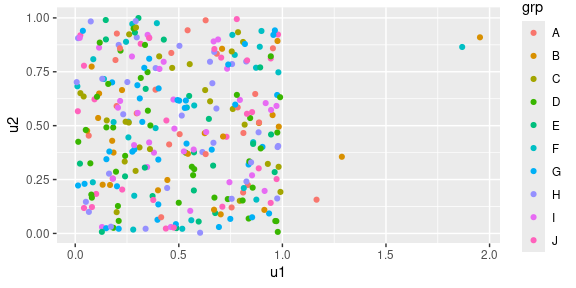

```r
ggplot(df, aes(x = u1, y = u2, color = grp)) +
  geom_point()
```

### The problem

Suppose you want focus the analysis on the levels `A` and `B`. It is not easy to identify where the points are because there is a lot of “noise” in the colors used due to the amount of levels of `grp`. A simple solution would be filtering out other groups.

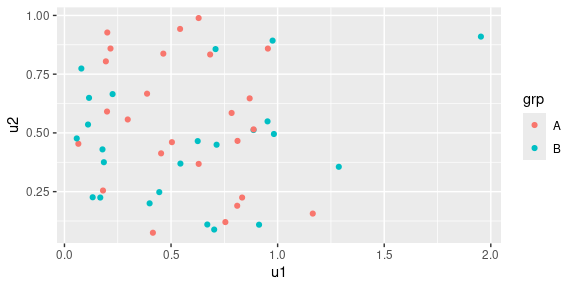

```r
library(dplyr)
df |>
  filter(grp %in% c("A", "B")) |>
  ggplot(aes(x = u1, y = u2, color = grp)) +
  geom_point()
```

While it solves the problems of too many colors making the viewer unable to quickly locate points of `A` and `B` and differentiate them, we did lose important information during the filtering, e.g., there are only 4 observations with `u1` greater than 1, and 3 of them are in the `grp` `A` or `B`. This is an important information contained in the data that should be considered when the analysis focuses on `A` and `B` but require the other observations (a **context**) in order to be obtained. Therefore, we want to focus on specific levels without taking them out of the **context** of the data.

### The solution

The solution to focus the analysis in the subgroup and keep the context is to use all the data but group each “unfocused” level in a new level and manipulate scales. This requires data wrangling and scale manipulation.

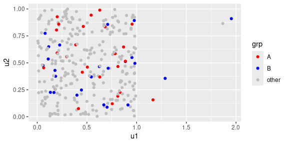

```r
df |>
  mutate(grp = ifelse(grp %in% c("A", "B"), as.character(grp), "other")) |>
  ggplot(aes(x = u1, y = u2, color = grp)) +
  geom_point() +
  scale_color_manual(values = c("A" = "red", "B" = "blue", "other" = "gray"))
```

This is a solution to the visualization but it required us to:

- use additional data wrangling functions.
- Priorly knowing that the set of colors `"red"`, `"blue"` and `"gray"` resulted in a focus on `"red"` and `"blue"`, therefore the `"gray"` color is the one that should be used on the unselected group.
- Type more.

### The goal of ggfocus

`ggfocus` has the goal of creating graphs that focus on a subgroup of the data like the one in the previous example, but without the three drawbacks mentioned. No data wrangling is required (it is all done internally), good scales for focusing on the subgroup are automatically created by default and as a result it is less verbose than selecting scales manually.

Not only `color` scales are available, but also scales for every other `aes` in `ggplot`: `fill`, `alpha`, `size`, `linetype`, `shape`, etc. Making it easy to guide the viewer towards the information to focus on using the most appropriate aesthetics for each graph.

The fact that `ggfocus` manipulates scales only, makes it usable with other extensions of `ggplot`. Examples using each scale are provided in this guide.

# ggfocus usage

## `color` and `fill`

```r
scale_color_focus(focus_levels, color_focus = NULL,
                  color_other = "gray", palette_focus = "Set1")

scale_fill_focus(focus_levels, color_focus = NULL,
  color_other = "gray", palette_focus = "Set1")
```

`color` and `fill` scales have the same default focus scales. They use the color `"gray"` for unselected observations and the `"Set1"` palette. Usually, a qualitative color scale is best to visualize the levels focused. The available palettes can be viewed with `RColorBrewer::display.brewer.all()`.

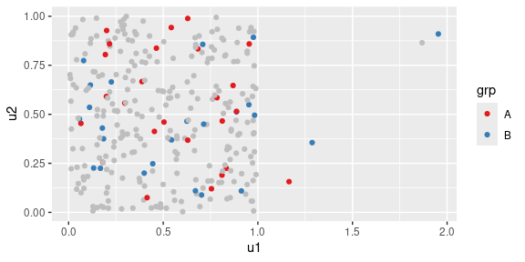

```r
ggplot(df, aes(x = u1, y = u2, color = grp)) +
  geom_point() +
  scale_color_focus(c("A", "B"))
```

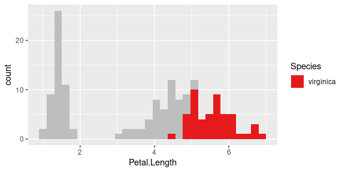

```r
ggplot(iris, aes(x = Petal.Length, fill = Species)) +
  geom_histogram() +
  scale_fill_focus("virginica")
```

One may also use a single color in the `color_focus` argument to make all the highlighted levels use the same color value. This allows to focus on the subroup as a whole instead of in its individual levels.

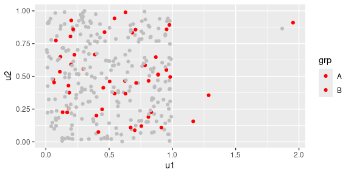

```r
ggplot(df, aes(x = u1, y = u2, color = grp)) +
  geom_point() +
  scale_color_focus(c("A", "B"), color_focus = "red")
```

## `alpha`

```r
scale_alpha_focus(focus_levels, alpha_focus = 1, alpha_other = 0.2)
```

`alpha` is probably one of the most important `aes` when drawing focus to specific subroups of your data as the transparency naturally removes the importance given to certain elements. It does not distinguish different groups, therefore it is usually used as a secondary highlighting scale. The argument `alpha_other` can be used to control the visibility if the unselected observations.

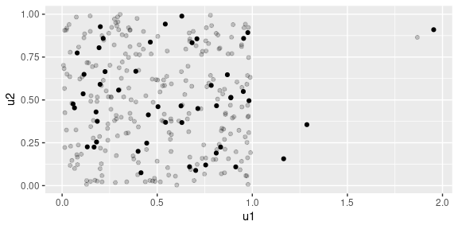

```r
ggplot(df, aes(x = u1, y = u2, alpha = grp)) +
  geom_point() +
  scale_alpha_focus(c("A", "B")) # Does not distinguish A and B.
```

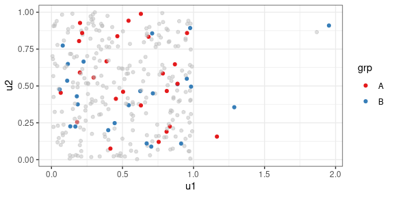

```r
ggplot(df, aes(x = u1, y = u2, alpha = grp, color = grp)) +
  geom_point() +
  scale_alpha_focus(c("A", "B"), alpha_other = 0.5) +
  scale_color_focus(c("A", "B")) +
  theme_bw() # White background
```

## `linetype`

```r
scale_linetype_focus(focus_levels, linetype_focus = 1, linetype_other = 3)
```

By default, a continuous line is used for focused levels and dotted line for other levels. Similar to `color`, one can pass a vector of values in `linetype_focus` to create different linetypes for each highlighted subgroup although the highest contrast is between continuous and dotted lines.

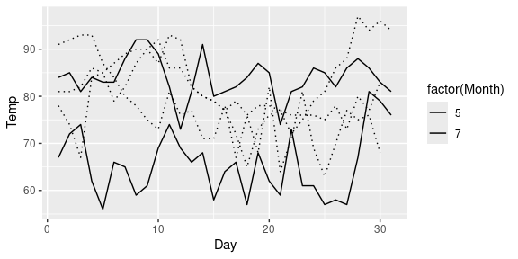

```r
ggplot(datasets::airquality, aes(x = Day, y = Temp, linetype = factor(Month),
                                 group = factor(Month))) +
  geom_line() +
  scale_linetype_focus(focus_levels = c(5,7))
```

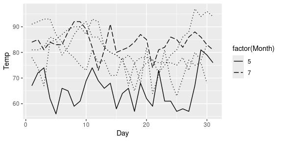

```r
ggplot(datasets::airquality, aes(x = Day, y = Temp, linetype = factor(Month),
                                 group = factor(Month))) +
  geom_line() +
  scale_linetype_focus(focus_levels = c(5,7), linetype_focus = c(1,5))
```

## `shape`

```r
scale_shape_focus(focus_levels, shape_focus = 8, shape_other = 1)
```

Not to useful to focus on subroups, but it is available. Works just like `linetype`.

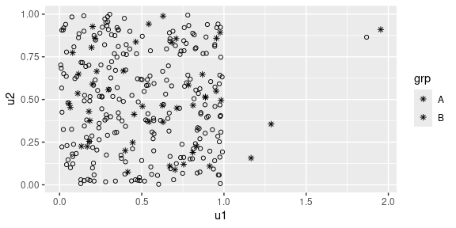

```r
ggplot(df, aes(x = u1, y = u2, shape = grp)) +
  geom_point() +
  scale_shape_focus(c("A", "B"))
```

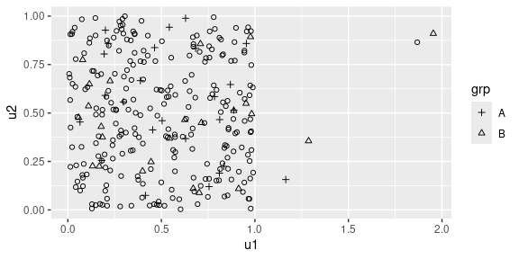

```r
ggplot(df, aes(x = u1, y = u2, shape = grp)) +
  geom_point() +
  scale_shape_focus(c("A", "B"), shape_focus = c(2,3))
```

## `size`

```r
scale_size_focus(focus_levels, size_focus = 3, size_other = 1)
```

Have similar properties as `alpha`, but using the size of the elements instead to reduce importance instead of transparency.

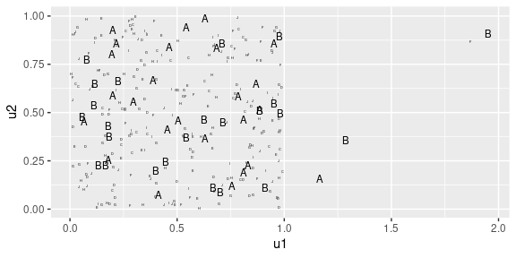

```r
ggplot(df, aes(x = u1, y = u2, size = grp)) +
  geom_text(aes(label = grp)) +
  scale_size_focus(c("A", "B"))
```

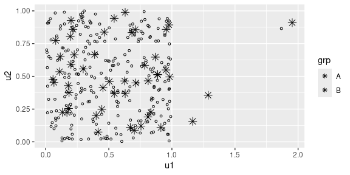

```r
ggplot(df, aes(x = u1, y = u2, size = grp, shape = grp)) +
  geom_point() +
  scale_size_focus(c("A", "B")) +
  scale_shape_focus(c("A", "B"))
```

## Interaction with other extensions

The main advantage of ggfocus lies in the fact it only manipulates scales to create the focus in the graphs. This fact allows it to interact with other `ggplot` extensions naturally, as it will work with any type of `geom`.

Some examples are below:

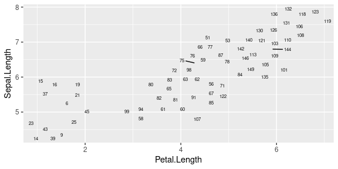

```r
library(dplyr)
library(ggrepel)
iris |>
  mutate(id = row_number()) |>
  ggplot(aes(x = Petal.Length, y = Sepal.Length, label = id, size = id)) +
  geom_text_repel() +
  scale_size_focus(c(100,127), size_focus = 8, size_other = 2)
```

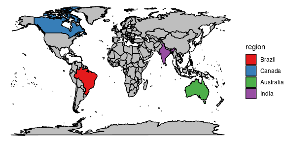

```r
library(maps)
wm <- map_data("world")
ggplot(wm, aes(x=long, y = lat, group = group, fill = region)) +
  geom_polygon(color="black") +
  theme_void() +
  scale_fill_focus(c("Brazil", "Canada", "Australia", "India"), color_other = "gray")
```